# Homework 4

李娜 Lina

2019年4月21日

## Part1 Data

```r
library(foreign)
gss<-read.dta("E:/博二/微观计量/Assignments/Homework/homework4/2018_stata/GSS2018.dta")
var<-c("age","sex", "sibs", "size","adults", "childs" ,"class", "coninc", "actssoc" ,"attend" ,"born", "cappun", "courts","degree", "earnrs", "ethnum", "famgen", "finalter", "finrela", "fund", "hhrace","madeg","marital","mobile16","natmass","natpark","othlang","natchld", "sexornt","partyid","phone","polviews","pres16","prestg10","natsci","quallife","race", "raclive","rank", "relig","reliten", "satfin","satsoc", "sei10","vetyears", "vote12", "happy", "weekswrk", "wrkslf", "wrkstat")
gss2<-gss[var]
gss3<-na.omit(gss2)
gss4<-subset(gss3,pres16=="trump" | pres16=="clinton")
gss4$pres16<-as.numeric((gss4$pres16))
gss4$pres16<-factor(gss4$pres16,levels = c(2,3),labels = c("Clinton","Trump"))
table(gss4$pres16)
```

```
##
## Clinton   Trump
##     260     195
```

```r
head(gss4,2)
```

```
##    age    sex sibs size adults childs         class   coninc   actssoc
## 5   71   male    3   14      2      0   upper class 158201.8 excellent
## 17  55 female    1   84      2      0 working class  70100.0      good
##              attend born cappun           courts   degree earnrs
## 5  more thn once wk  yes oppose not harsh enough graduate      1
## 17   lt once a year  yes oppose        too harsh bachelor      2
##             ethnum famgen    finalter           finrela     fund hhrace
## 5  chooses 1 of 2+  1 gen stayed same far above average moderate  white
## 17 chooses 1 of 2+  1 gen       worse     below average  liberal  white
##          madeg  marital         mobile16    natmass    natpark othlang
## 5  high school divorced  different state too little too little      no
## 17 high school  married same st,dif city too little too little     yes
##        natchld                  sexornt           partyid         phone
## 5  about right heterosexual or straight strong republican phone in home
## 17  too little heterosexual or straight      ind,near dem phone in home
##                polviews  pres16 prestg10     natsci  quallife  race
## 5  extrmly conservative   Trump       53 too little very good black
## 17              liberal Clinton       64 too little      fair white
##    raclive rank    relig     reliten         satfin    satsoc sei10
## 5      yes    5 catholic      strong      satisfied excellent  68.6
## 17     yes    5     none no religion not at all sat      good  84.2
##           vetyears vote12         happy weekswrk       wrkslf
## 5  more than 4 yrs  voted  pretty happy        0 someone else
## 17 more than 4 yrs  voted not too happy       52 someone else
##             wrkstat
## 5           retired
## 17 unempl, laid off
```

```r
set.seed(421)
# Split the data into training and testing
n<-nrow(gss4)
train<-sample(n,0.7*n)
gss.tr<-gss4[train,]
gss.te<-gss4[-train,]
table(gss.tr$pres16)
```

```
##
## Clinton   Trump
##     186     132
```

## Part2 Logistic Regression

```r
# Logistic Regression
logitfit<-glm(pres16~.,gss.tr,family = "binomial")
require(AER)
coeftest(logitfit)
```

```
##
## z test of coefficients:
##
##                                    Estimate  Std. Error z value Pr(>|z|)
## (Intercept)                     -1.2778e+02  1.2705e+06  -1e-04   0.9999
## age                              1.1357e-01  1.0652e+04   0e+00   1.0000
## sexfemale                       -1.4131e+01  1.0075e+05  -1e-04   0.9999
## sibs                             8.4030e-01  5.7452e+04   0e+00   1.0000
## size                             2.6483e-03  5.2248e+01   1e-04   1.0000
## adults                           4.4077e+00  1.3584e+05   0e+00   1.0000
## childs                          -1.6071e+00  6.6574e+04   0e+00   1.0000
## classworking class              -1.8761e+01  5.1854e+05   0e+00   1.0000
## classmiddle class               -1.3923e+01  4.4593e+05   0e+00   1.0000
## classupper class                 2.2773e+00  3.7176e+05   0e+00   1.0000
## coninc                           1.5214e-04  3.3064e+00   0e+00   1.0000
## actssocvery good                 2.3187e+01  2.9986e+05   1e-04   0.9999
## actssocgood                      1.1684e+01  3.2931e+05   0e+00   1.0000
## actssocfair                      1.5550e+01  9.1557e+05   0e+00   1.0000
## actssocpoor                      3.5680e+01  9.5019e+05   0e+00   1.0000
## attendlt once a year            -3.9879e+00  2.8777e+05   0e+00   1.0000
## attendonce a year               -2.0112e+00  4.7753e+05   0e+00   1.0000
## attendsevrl times a yr           2.0225e+01  3.2161e+05   1e-04   0.9999
## attendonce a month               3.6511e+00  7.5166e+05   0e+00   1.0000
## attend2-3x a month               1.3007e-02  2.5706e+05   0e+00   1.0000
## attendnrly every week            3.4919e+01  3.2870e+05   1e-04   0.9999
## attendevery week                 2.2281e+01  3.0460e+05   1e-04   0.9999
## attendmore thn once wk           2.4431e+01  6.0908e+05   0e+00   1.0000
## bornno                          -2.2920e+01  2.9308e+05  -1e-04   0.9999
## cappunoppose                    -5.6847e+00  2.3253e+05   0e+00   1.0000
## courtsnot harsh enough          -5.7310e+00  2.3567e+05   0e+00   1.0000
## courtsabout right               -3.0560e+01  4.6032e+05  -1e-04   0.9999
## degreehigh school               -2.0645e+00  3.7399e+05   0e+00   1.0000
## degreejunior college             3.0518e-02  4.7746e+05   0e+00   1.0000
## degreebachelor                  -1.3010e+01  3.7044e+05   0e+00   1.0000
## degreegraduate                  -2.1532e+00  5.6728e+05   0e+00   1.0000
## earnrs                          -1.1108e+01  9.1798e+04  -1e-04   0.9999
## ethnumchooses 1 of 2+           -7.0286e+00  2.9374e+05   0e+00   1.0000
## ethnumcannot choose 1           -1.1053e+00  2.8506e+05   0e+00   1.0000
## ethnumcannot name any           -3.4632e+00  6.5861e+05   0e+00   1.0000
## famgen2 gens, children           2.0151e+01  2.0714e+05   1e-04   0.9999
```

[output cut: 78 more lines]

```
## vetyears2 to 4  years            9.7417e+00  4.6645e+05   0e+00   1.0000
## vetyearsmore than 4 yrs         -2.9443e+01  5.3720e+05  -1e-04   1.0000
## vote12did not vote               6.6222e+00  1.9895e+05   0e+00   1.0000
## vote12ineligible                 1.4308e+01  3.7570e+05   0e+00   1.0000
## happypretty happy                1.0674e+01  1.3405e+05   1e-04   0.9999
## happynot too happy               8.4333e+00  2.9019e+05   0e+00   1.0000
## weekswrk                         6.5766e-02  8.6408e+03   0e+00   1.0000
## wrkslfsomeone else               1.1816e+01  4.4319e+05   0e+00   1.0000
## wrkstatworking parttime         -1.1886e+01  3.0699e+05   0e+00   1.0000
## wrkstattemp not working         -2.4228e+01  3.0901e+05  -1e-04   0.9999
## wrkstatunempl, laid off          2.1273e+01  9.1309e+05   0e+00   1.0000
## wrkstatretired                  -1.3686e+01  3.7587e+05   0e+00   1.0000
## wrkstatschool                    1.9345e+01  8.3203e+05   0e+00   1.0000
## wrkstatkeeping house            -8.7667e+00  5.1185e+05   0e+00   1.0000
## wrkstatother                    -7.9262e+00  4.7461e+07   0e+00   1.0000
```

```r
p<-predict(logitfit,gss.te,type="response")
logitpred<-as.factor(p>.5)
logitpred<-factor(logitpred,levels = c("FALSE","TRUE"),labels=c("Clinton","Trump"))
table(logitpred,gss.te$pres16)
```

```
##
## logitpred Clinton Trump
##   Clinton      65    14
##   Trump         9    49
```

```r
logiterr<-1-mean(logitpred==gss.te$pres16)
logiterr
```

```
## [1] 0.1678832
```

It seems the result of logistic regression is terrible.

## Part3 Lasso, Ridge and Elastic Net

### (1) Lasso

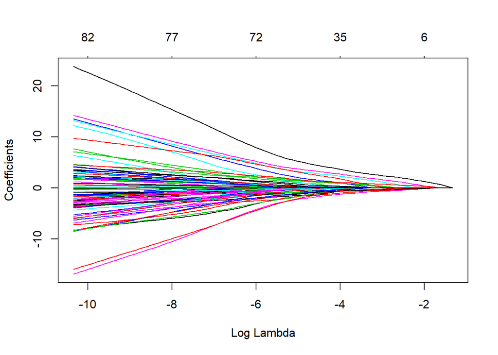

```r
## Lasso
require(glmnet)
xvar<-model.matrix(pres16~.,gss.tr)[,-1]
yvar<-gss.tr$pres16
lasso.fit<-glmnet(xvar,yvar,alpha = 1,family = "binomial")
plot(lasso.fit,xvar = "lambda")
```

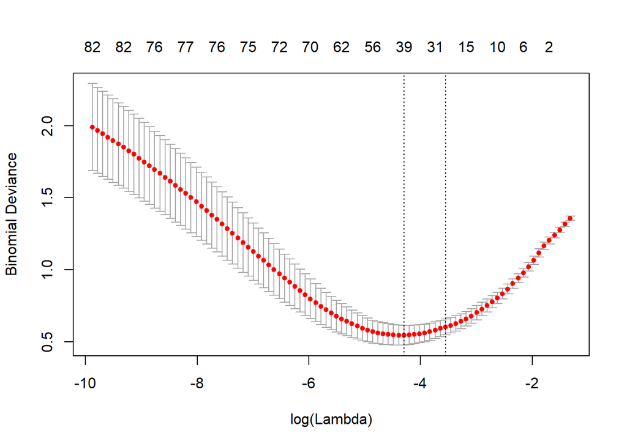

```r
cv.lasso<-cv.glmnet(xvar,yvar,family="binomial")
plot(cv.lasso)
```

```r
lambda.star<-cv.lasso$lambda.min
lassofit.star<-glmnet(xvar,yvar,alpha=1, lambda = lambda.star,family = "binomial")
xvar.te<-model.matrix(pres16~.,gss.te)[,-1]
lassopred<-predict(lassofit.star,xvar.te,type = "class")
table(lassopred,gss.te$pres16)
```

```
##
## lassopred Clinton Trump
##   Clinton      72    12
##   Trump         2    51
```

```r
lassoerr<-1-mean(lassopred==gss.te$pres16)
lassoerr
```

```
## [1] 0.1021898
```

### (2) Ridge

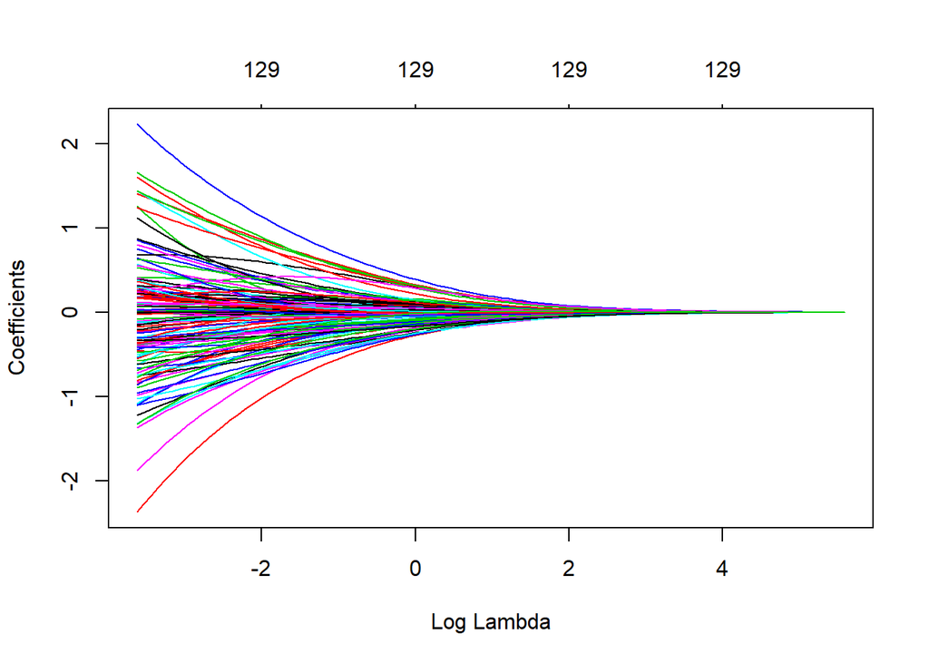

```r
## Ridge
ridge.fit<-glmnet(xvar,yvar,alpha = 0,family = "binomial")
plot(ridge.fit,xvar = "lambda")
```

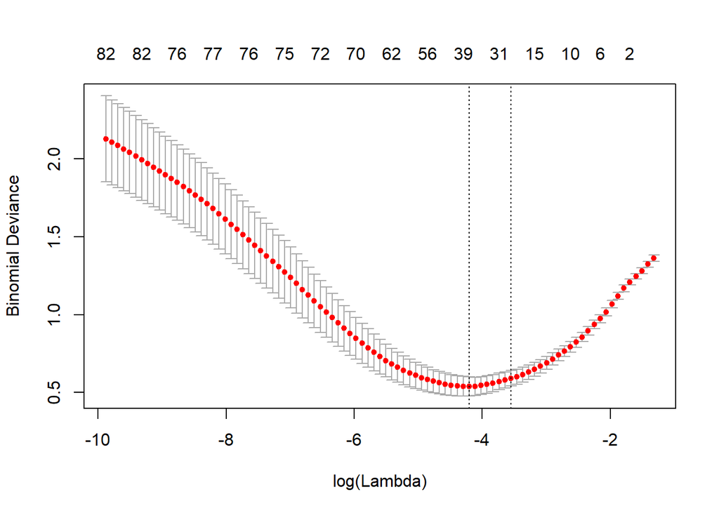

```r
cv.ridge<-cv.glmnet(xvar,yvar,family="binomial")
plot(cv.ridge)
```

```r
lambda.star<-cv.ridge$lambda.min
ridgefit.star<-glmnet(xvar,yvar,alpha=0, lambda = lambda.star,family = "binomial")
ridgepred<-predict(ridgefit.star,xvar.te,type = "class")
table(ridgepred,gss.te$pres16)
```

```
##
## ridgepred Clinton Trump
##   Clinton      69    12
##   Trump         5    51
```

```r
ridgeerr<-1-mean(ridgepred==gss.te$pres16)
ridgeerr
```

```
## [1] 0.1240876
```

### (3) Elastic Net

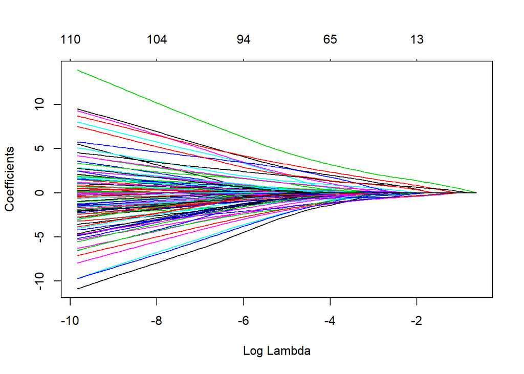

```r
# Elastic net
elastic.fit<-glmnet(xvar,yvar,alpha = 0.5,family = "binomial")
plot(elastic.fit,xvar = "lambda")
```

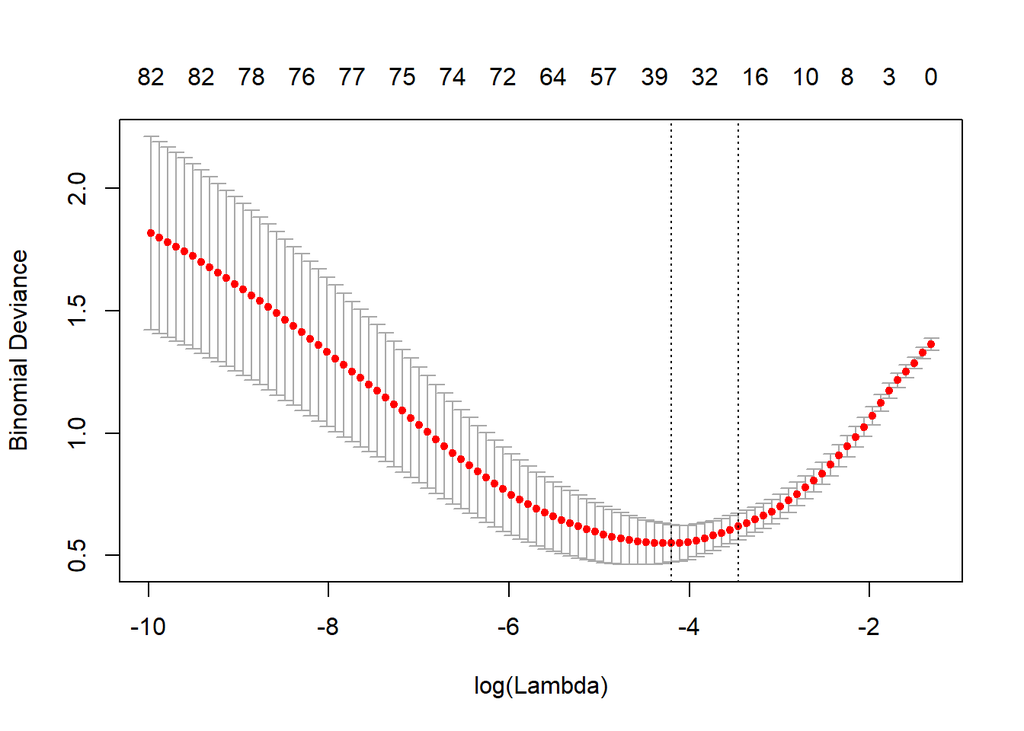

```r
cv.elastic<-cv.glmnet(xvar,yvar,family="binomial")
plot(cv.elastic)
```

```r
lambda.star<-cv.elastic$lambda.min
elasticfit.star<-glmnet(xvar,yvar,alpha=0.5, lambda = lambda.star,family = "binomial")
elasticpred<-predict(elasticfit.star,xvar.te,type = "class")
table(elasticpred,gss.te$pres16)
```

```
##
## elasticpred Clinton Trump
##     Clinton      71    10
##     Trump         3    53
```

```r
elasticerr<-1-mean(elasticpred==gss.te$pres16)
elasticerr
```

```
## [1] 0.09489051
```

Comparing the missification rate, we can find **elastic net** perfoems better.

## Part4 Variable Analysis

```r
coef(elasticfit.star)
```

```
## 240 x 1 sparse Matrix of class "dgCMatrix"
##                                            s0
## (Intercept)                     -2.952965e+00
## age                              .
## sexfemale                       -2.364267e-01
## sibs                             .
## size                             .
## adults                           9.551941e-02
## childs                           .
## classworking class               .
## classmiddle class               -1.352658e-01
## classupper class                 1.415201e-01
## classno class                    .
## classDK                          .
## classIAP                         .
## classNA                          .
## coninc                           1.128126e-06
## actssocvery good                 .
## actssocgood                     -6.599542e-02
## actssocfair                     -1.100266e+00
## actssocpoor                      .
## actssocDon't know                .
## actssocIAP                       .
## actssocNo answer                 .
## attendlt once a year             .
## attendonce a year               -4.848587e-01
## attendsevrl times a yr           6.310961e-02
## attendonce a month               .
## attend2-3x a month               .
## attendnrly every week            .
## attendevery week                 .
## attendmore thn once wk           .
## attendDK,NA                      .
## bornno                          -1.120597e+00
## bornDK                           .
## bornIAP                          .
## bornNA                           .
## cappunoppose                    -8.037635e-01
## cappunDK                         .
## cappunIAP                        .
```

[output cut: 187 more lines]

```
## happyNA                          .
## weekswrk                         .
## wrkslfsomeone else               .
## wrkslfDK                         .
## wrkslfIAP                        .
## wrkslfNA                         .
## wrkstatworking parttime         -2.509262e-01
## wrkstattemp not working          .
## wrkstatunempl, laid off          .
## wrkstatretired                   .
## wrkstatschool                    .
## wrkstatkeeping house             .
## wrkstatother                     .
## wrkstatIAP                       .
## wrkstatNA                        .
```

From above results, we can find, with elastic net regression, many coefficients are shrinked towards zero. But there still are some variables influcing people’s vote. Such as political party affiliation, if the person is more conservative and in strong republican,he (she) will be more likely to vote for Trump(obviously!). Besides, sex, marriage, social class,attitudes towards courts dealing with criminals and death penalty for murder also have effects on the voting.